# Assignment 2: Spatial Analysis and Visualization

Healthcare Access and Equity in Pennsylvania

Author

Hope Levin

Published

October 13, 2025

## Assignment Overview

**Learning Objectives:** - Apply spatial operations to answer policy-relevant research questions - Integrate census demographic data with spatial analysis - Create publication-quality visualizations and maps - Work with spatial data from multiple sources - Communicate findings effectively for policy audiences

## Part 1: Healthcare Access for Vulnerable Populations

### Research Question

**Which Pennsylvania counties have the highest proportion of vulnerable populations (elderly + low-income) living far from hospitals?**

Your analysis should identify counties that should be priorities for healthcare investment and policy intervention.

### Required Analysis Steps

Complete the following analysis, documenting each step with code and brief explanations:

#### Step 1: Data Collection (5 points)

Load the required spatial data: - Pennsylvania county boundaries - Pennsylvania hospitals (from lecture data) - Pennsylvania census tracts

**Your Task:**

```r
# Load required packages
library(sf)
library(tidyverse)
library(tigris)
library(tidycensus)
library(scales)
library(patchwork)
library(here)
library(dplyr)
library(knitr)
library(ggplot2)

# Census API key
census_api_key(Sys.getenv("CENSUS_API_KEY"), install = FALSE)

#| message: false
#| warning: false
#| echo: true

# Load spatial data
pa_counties <- st_read("data/Pennsylvania_County_Boundaries.shp")
hospitals <- st_read("data/hospitals.geojson")
census_tracts <- tracts(state = "PA", cb = TRUE)
# Questions to answer:
hospitals %>%
  group_by(FACILITY_N) %>%
  summarise(count = n())
```

```
Simple feature collection with 222 features and 2 fields
Geometry type: POINT
Dimension:     XY
Bounding box:  xmin: -80.49621 ymin: 39.75163 xmax: -74.86704 ymax: 42.13403
Geodetic CRS:  WGS 84
# A tibble: 222 × 3
   FACILITY_N                                    count             geometry
   <chr>                                         <int>          <POINT [°]>
 1 ADVANCED SURGICAL HOSPITAL                        1 (-80.27907 40.15655)
 2 AHN Canonsburg Hospital                           1 (-80.19077 40.24585)
 3 AHN Emerus Westmoreland Neighborhood Hospital     1 (-79.60014 40.31084)
 4 AHN Jefferson Hospital                            1 (-79.93342 40.31745)
 5 AHN Saint Vincent Hospital                        1 (-80.07954 42.11131)
 6 AHN-Allegheny General Hospital                    1 (-80.00332 40.45695)
 7 AVENUES RECOVERY MEDICAL CENTER AT VALLEY FO…     1 (-75.36752 40.15866)
 8 Albert Einstein Medical Center                    1 (-75.14335 40.03696)
 9 Allegheny Health Network Wexford Hospital         1  (-80.0624 40.63554)
10 Allegheny Valley Hospital                         1 (-79.73647 40.61824)
# ℹ 212 more rows
```

```r
census_tracts %>%
  group_by(GEOID) %>%
  summarise(count = n())
```

```
Simple feature collection with 3445 features and 2 fields
Geometry type: GEOMETRY
Dimension:     XY
Bounding box:  xmin: -80.51989 ymin: 39.7198 xmax: -74.68952 ymax: 42.26986
Geodetic CRS:  NAD83
# A tibble: 3,445 × 3
   GEOID       count                                                    geometry
   <chr>       <int>                                               <POLYGON [°]>
 1 42001030101     1 ((-77.15032 40.04536, -77.15219 40.04152, -77.14124 40.036…
 2 42001030103     1 ((-77.06828 39.97375, -77.06277 39.97149, -77.05646 39.968…
 3 42001030104     1 ((-77.09913 39.94784, -77.0904 39.94587, -77.08214 39.9481…
 4 42001030200     1 ((-77.23764 40.01404, -77.21936 40.00666, -77.21849 40.006…
 5 42001030300     1 ((-77.42136 39.98129, -77.3946 39.96514, -77.38766 39.9589…
 6 42001030400     1 ((-77.46961 39.91617, -77.46863 39.90723, -77.46876 39.903…
 7 42001030500     1 ((-77.29438 39.93242, -77.2939 39.92694, -77.29242 39.9248…
 8 42001030600     1 ((-77.22819 39.89023, -77.22149 39.88539, -77.22534 39.882…
 9 42001030700     1 ((-77.18479 39.8121, -77.17674 39.80536, -77.1762 39.805, …
10 42001030801     1 ((-77.02221 39.86435, -77.01868 39.85995, -77.00403 39.836…
# ℹ 3,435 more rows
```

```r
st_crs(pa_counties)
```

[output not shown]

```r
st_crs(hospitals)
```

```
Coordinate Reference System:
  User input: WGS 84
  wkt:
GEOGCRS["WGS 84",
    DATUM["World Geodetic System 1984",
        ELLIPSOID["WGS 84",6378137,298.257223563,
            LENGTHUNIT["metre",1]]],
    PRIMEM["Greenwich",0,
        ANGLEUNIT["degree",0.0174532925199433]],
    CS[ellipsoidal,2],
        AXIS["geodetic latitude (Lat)",north,
            ORDER[1],
            ANGLEUNIT["degree",0.0174532925199433]],
        AXIS["geodetic longitude (Lon)",east,
            ORDER[2],
            ANGLEUNIT["degree",0.0174532925199433]],
    ID["EPSG",4326]]
```

```r
st_crs(census_tracts)
```

```
Coordinate Reference System:
  User input: NAD83
  wkt:
GEOGCRS["NAD83",
    DATUM["North American Datum 1983",
        ELLIPSOID["GRS 1980",6378137,298.257222101,
            LENGTHUNIT["metre",1]]],
    PRIMEM["Greenwich",0,
        ANGLEUNIT["degree",0.0174532925199433]],
    CS[ellipsoidal,2],
        AXIS["latitude",north,
            ORDER[1],
            ANGLEUNIT["degree",0.0174532925199433]],
        AXIS["longitude",east,
            ORDER[2],
            ANGLEUNIT["degree",0.0174532925199433]],
    ID["EPSG",4269]]
```

**Questions to answer:**

How many hospitals are in your dataset?

How many census tracts?

- 3,445 census tracts

What coordinate reference system is each dataset in? :

- pa_counties: WGS 84 / Pseudo-Mercator EPSG: 3857
- hospitals: WGS 84 EPSG: 4326
- census_tracts: NAD83 EPSG: 4269

#### Step 2: Get Demographic Data

Use `tidycensus` to download tract-level demographic data for Pennsylvania.

**Required variables:** - Total population - Median household income - Population 65 years and over (you may need to sum multiple age categories)

**Your Task:**

```r
# Get demographic data from ACS
pa_tract_data <- get_acs(
  geography = "tract",
  state = "Pennsylvania",
  variables = c(
    total_population = "B01003_001",
    median_income = "B19013_001",
    over_65 = "B01001_020"),
  survey = "acs5",
  year = 2022,
  output = "wide"
)

# Join to tract boundaries
census_tracts <- census_tracts %>%
  left_join(pa_tract_data, by = "GEOID")

# Questions to answer:
pa_tract_data %>%
  filter(is.na(median_incomeE)) %>%
  count()
```

```
# A tibble: 1 × 1
      n
  <int>
1    63
```

```r
median(pa_tract_data$median_incomeE, na.rm = TRUE)
```

```
[1] 70188
```

**Questions to answer:**

What year of ACS data are you using?

- 2022 ACS data

How many tracts have missing income data?

- 63 tracts

What is the median income across all PA census tracts?

- $70,188

#### Step 3: Define Vulnerable Populations

Identify census tracts with vulnerable populations based on TWO criteria: 1. Low median household income (choose an appropriate threshold) 2. Significant elderly population (choose an appropriate threshold)

**Your Task:**

```r
# Filter for vulnerable tracts based on your criteria
income_threshold <- quantile (
  census_tracts$median_incomeE, 0.25, na.rm = TRUE)
# $55,924

census_tracts <- census_tracts %>%
  mutate(pct_over_65 = (over_65E / total_populationE) *100)

age_threshold <- quantile (
  census_tracts$pct_over_65, 0.75, na.rm = TRUE)

vulnerable_pop <- census_tracts %>%
  filter(
    median_incomeE < income_threshold,
    pct_over_65 > age_threshold
  )

vulnerable_pop <- vulnerable_pop %>%
  mutate(
    vulnerable = median_incomeE < income_threshold & pct_over_65 > age_threshold
  )
```

**Questions to answer:**

What income threshold did you choose and why?

- My income threshold is the bottom 25%, or $55,924. By going with a quantile approach, I was able to determine the cutoff in context of the entire state.

What elderly population threshold did you choose and why?

- Again, I went with a quantile approach for contextual understanding. However, I choose the top 25% as I was interested in seeing tracts with large elderly populations.

How many tracts meet your vulnerability criteria?

- 168 tracts meet both criterias.

What percentage of PA census tracts are considered vulnerable by your definition?

- 4.87% of tracts.

#### Step 4: Calculate Distance to Hospitals

For each vulnerable tract, calculate the distance to the nearest hospital.

**Your Task:**

```r
# Transform to appropriate projected CRS
vulnerable_pop <- st_transform(vulnerable_pop, crs = 3365)

hospitals <- st_transform(hospitals, crs = 3365)

# Calculate distance from each tract centroid to nearest hospital
tract_centroid <- st_centroid(vulnerable_pop)

distance_matrix <- st_distance(tract_centroid, hospitals)

vulnerable_pop <- vulnerable_pop %>%
  mutate(
    hospital_dis = apply(distance_matrix, 1, min),
    hospital_miles = as.numeric(hospital_dis) / 1609.34)

# Questions to answer
vulnerable_pop %>%
  summarise(
    avg_distance = mean(hospital_miles, na.rm = TRUE),
    max_distance = max(hospital_miles, na.rm = TRUE),
    over_15 = sum(hospital_miles > 15, na.rm = TRUE)
)
```

```
Simple feature collection with 1 feature and 3 fields
Geometry type: MULTIPOLYGON
Dimension:     XY
Bounding box:  xmin: 1204220 ymin: 145044.8 xmax: 2727730 ymax: 1029901
Projected CRS: NAD83(HARN) / Pennsylvania South (ftUS)
  avg_distance max_distance over_15                       geometry
1     13.46201     62.85519      47 MULTIPOLYGON (((1337166 245...
```

**Requirements:** - Use an appropriate projected coordinate system for Pennsylvania - Calculate distances in miles - Explain why you chose your projection

- I chose Pennsylvania State Plane South, as it is the projection that I am most comfortable mapping with.

**Questions to answer:**

What is the average distance to the nearest hospital for vulnerable tracts?

- The average distance to the nearest tract for vulnerable tracts is 13.5 miles.

What is the maximum distance?

- The maximum distance is 62.9 miles.

How many vulnerable tracts are more than 15 miles from the nearest hospital?

- 47 tracts are more than 15 miles away from the nearest hospital.

#### Step 5: Identify Underserved Areas

Define “underserved” as vulnerable tracts that are more than 15 miles from the nearest hospital.

**Your Task:**

```r
# Create underserved variable
vulnerable_pop <- vulnerable_pop %>%
  mutate(
    underserved = hospital_miles > 15 & median_incomeE < income_threshold & pct_over_65 > age_threshold
  )

# Questions to answer
vulnerable_pop %>%
  summarise(
    underserved_count = sum(underserved, na.rm = TRUE),
    total_tracts = n (),
    underserved_pct = (underserved_count/total_tracts)*100
  )
```

```
Simple feature collection with 1 feature and 3 fields
Geometry type: MULTIPOLYGON
Dimension:     XY
Bounding box:  xmin: 1204220 ymin: 145044.8 xmax: 2727730 ymax: 1029901
Projected CRS: NAD83(HARN) / Pennsylvania South (ftUS)
  underserved_count total_tracts underserved_pct                       geometry
1                47          168        27.97619 MULTIPOLYGON (((1337166 245...
```

**Questions to answer:**

How many tracts are underserved?

- 47 tracts are underserved.

What percentage of vulnerable tracts are underserved?

- Roughly 28% of tracts are underserved.

Does this surprise you? Why or why not?

- Somewhat…having gone to college in upstate New York, I’m well aware of healthcare access disparities in rural America. However, I was anticipating the number to be much lower, around 20-25%. Shocking that such a high barrier exists given the supposed advancements in this country.

#### Step 6: Aggregate to County Level

Use spatial joins and aggregation to calculate county-level statistics about vulnerable populations and hospital access.

**Your Task:**

```r
# Spatial join tracts to counties
pa_counties <- st_transform(pa_counties, crs = 3365)
vulnerable_pop <- st_transform(vulnerable_pop, crs = 3365)

tracts_with_counties <- vulnerable_pop %>%
  st_join(pa_counties %>% select(COUNTY_NAM))

# Aggregate statistics by county
county_stats <- tracts_with_counties %>%
  st_drop_geometry() %>%
  group_by(COUNTY_NAM) %>%
  summarise(
    total_tracts = n(),
    vulnerable_num = sum(vulnerable, na.rm = TRUE),
    underserved_num = sum(underserved, na.rm =TRUE),
    pct_underserved = (underserved_num/vulnerable_num)*100,
    hosp_dist = mean(hospital_miles, na.rm = TRUE),
    total = sum (total_populationE, na.rm = TRUE)
  ) %>%
  ungroup()
```

**Required county-level statistics:** - Number of vulnerable tracts - Number of underserved tracts  
- Percentage of vulnerable tracts that are underserved - Average distance to nearest hospital for vulnerable tracts - Total vulnerable population

**Questions to answer:**

Which 5 counties have the highest percentage of underserved vulnerable tracts?

- I found that 21 counties share the same percentage of underserved vulnerable tracts - Armstrong, Cameron, Clarion, Clinton, Elk, Forest, Franklin, Fulton, Greene, Huntingdon, Indiana, Jefferson, Juniata, Lebanon, McKean, Monroe, Norththumberland, Perry, Potter, Somerset, and Tioga.

Which counties have the most vulnerable people living far from hospitals?

- The top 5 counties of vulnerable people living from hospitals are 1. Monroe (58 miles), Perry, Franklin, Juniata, 5. Forest (50 miles).

Are there any patterns in where underserved counties are located?

#### Step 7: Create Summary Table

Create a professional table showing the top 10 priority counties for healthcare investment.

**Your Task:**

```r
# Create and format priority counties table
priority_counties <- county_stats %>%
  arrange(desc(hosp_dist)) %>%
    slice(1:10) %>%
  select(COUNTY_NAM, total_tracts, total, pct_underserved, hosp_dist)

kable(priority_counties,
      col.names = c("County", "Vulnerable Tracts", "Total Population", "Underserved Vulnerable Tracts (%)", "Distance to Nearest Hospital (mi)"),
      caption = "Top 10 Priority Counties for Healthcare Investment",
      format.args = list(big.mark = ",")
)
```

Top 10 Priority Counties for Healthcare Investment

| County | Vulnerable Tracts | Total Population | Underserved Vulnerable Tracts (%) | Distance to Nearest Hospital (mi) |
| --- | --- | --- | --- | --- |
| MONROE | 1 | 1,299 | 100 | 58.02058 |
| PERRY | 2 | 5,800 | 100 | 57.52312 |
| FRANKLIN | 1 | 1,782 | 100 | 52.19105 |
| JUNIATA | 1 | 1,782 | 100 | 52.19105 |
| FOREST | 2 | 4,406 | 100 | 50.03962 |
| CLARION | 2 | 4,750 | 100 | 47.65747 |
| SOMERSET | 1 | 2,138 | 100 | 46.97646 |
| TIOGA | 2 | 6,865 | 100 | 46.44334 |
| HUNTINGDON | 2 | 5,111 | 100 | 43.53532 |
| NORTHUMBERLAND | 7 | 21,415 | 100 | 43.15381 |

**Requirements:** - Use `knitr::kable()` or similar for formatting - Include descriptive column names - Format numbers appropriately (commas for population, percentages, etc.) - Add an informative caption - Sort by priority (you decide the metric)

## Part 2: Comprehensive Visualization

Using the skills from Week 3 (Data Visualization), create publication-quality maps and charts.

### Map 1: County-Level Choropleth

Create a choropleth map showing healthcare access challenges at the county level.

**Your Task:**

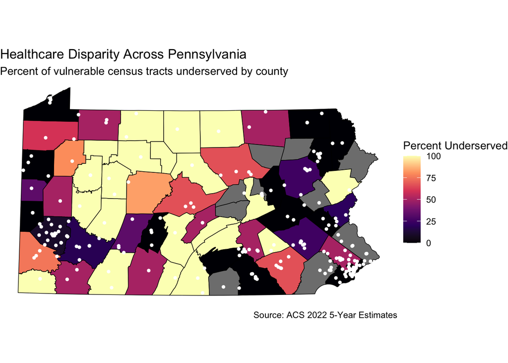

```r
# Create county-level access map
county_map <- pa_counties %>%
  st_transform(crs = st_crs(vulnerable_pop)) %>%
  left_join(county_stats, by = "COUNTY_NAM")

hospitals <- st_transform(hospitals, crs = 3365)

ggplot() +
  geom_sf(data = county_map,
          aes(fill = pct_underserved),
          color = "black", size = .25) +
  geom_sf(data = hospitals,
          color = "white",
          size = 1) +
  scale_fill_viridis_c(
    name = "Percent Underserved",
    option = "magma"
  ) +
  labs(
    title = "Healthcare Disparity Across Pennsylvania",
    subtitle = "Percent of vulnerable census tracts underserved by county",
    caption = "Source: ACS 2022 5-Year Estimates"
  ) +
  theme_void()
```

**Requirements:** - Fill counties by percentage of vulnerable tracts that are underserved - Include hospital locations as points - Use an appropriate color scheme - Include clear title, subtitle, and caption - Use `theme_void()` or similar clean theme - Add a legend with formatted labels

### Map 2: Detailed Vulnerability Map

Create a map highlighting underserved vulnerable tracts.

**Your Task:**

```r
# Create detailed tract-level map
vulnerable_pop <- vulnerable_pop %>%
  mutate(
    underserved_flag = ifelse (underserved == TRUE, "Underserved", "Other")
  )

unique(vulnerable_pop$underserved_flag)
```

```
[1] "Underserved" "Other"
```

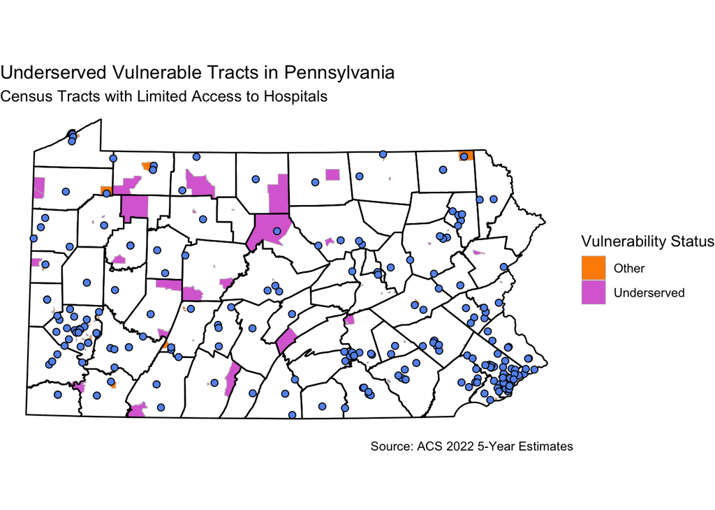

```r
ggplot () +
  geom_sf(data = vulnerable_pop,
          aes(fill = underserved_flag),
          color = "grey")+
  geom_sf(data = pa_counties,
          fill = NA,
          color = "black",
          size = 0.5) +
  geom_sf(data = hospitals,
          size = 2,
          shape = 21,
          fill = "cornflowerblue")+
  scale_fill_manual(values = c("Underserved" = "orchid",
                                  "Other" = "darkorange"),
                    name = "Vulnerability Status")+
  labs(
    title = "Underserved Vulnerable Tracts in Pennsylvania",
    subtitle = "Census Tracts with Limited Access to Hospitals",
    caption = "Source: ACS 2022 5-Year Estimates"
  )+
  theme_void()
```

**Requirements:** - Show underserved vulnerable tracts in a contrasting color - Include county boundaries for context - Show hospital locations - Use appropriate visual hierarchy (what should stand out?) - Include informative title and subtitle

### Chart: Distribution Analysis

Create a visualization showing the distribution of distances to hospitals for vulnerable populations.

**Your Task:**

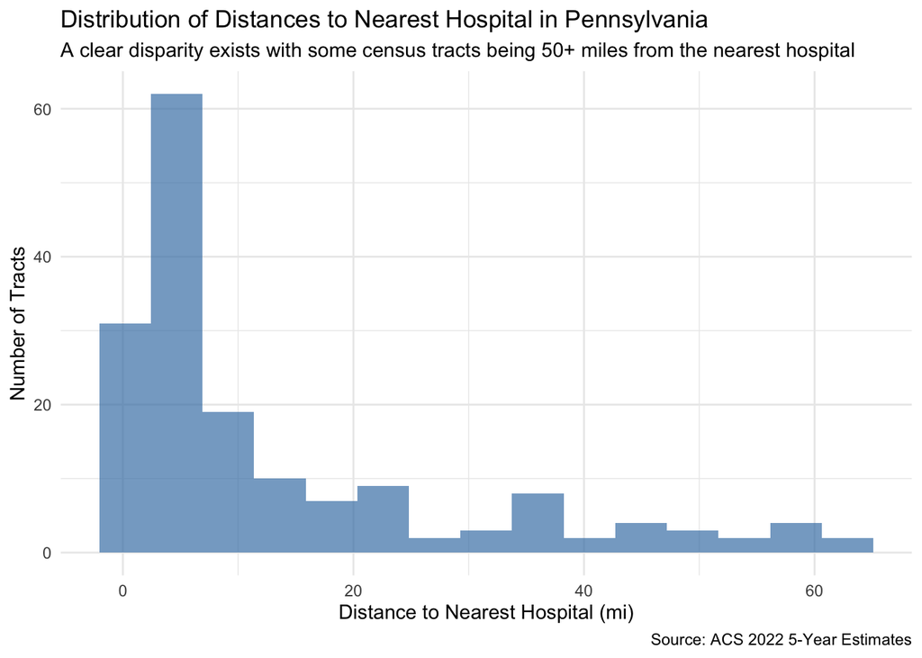

```r
# Create distribution visualization
ggplot(vulnerable_pop, aes(x = hospital_miles)) +
         geom_histogram(bins = 15, fill = "steelblue", alpha = 0.7) +
         labs(
           title = "Distribution of Distances to Nearest Hospital in Pennsylvania",
           subtitle = "A clear disparity exists with some census tracts being 50+ miles from the nearest hospital",
           x = "Distance to Nearest Hospital (mi)",
           y = "Number of Tracts",
           caption = "Source: ACS 2022 5-Year Estimates"
         )+
         theme_minimal()
```

**Suggested chart types:** - Histogram or density plot of distances - Box plot comparing distances across regions - Bar chart of underserved tracts by county - Scatter plot of distance vs. vulnerable population size

**Requirements:** - Clear axes labels with units - Appropriate title - Professional formatting - Brief interpretation (1-2 sentences as a caption or in text)

## Part 3: Bring Your Own Data Analysis

Choose your own additional spatial dataset and conduct a supplementary analysis.

### Challenge Options

Choose ONE of the following challenge exercises, or propose your own research question using OpenDataPhilly data (https://opendataphilly.org/datasets/).

**Note these are just loose suggestions to spark ideas - follow or make your own as the data permits and as your ideas evolve. This analysis should include bringing in your own dataset, ensuring the projection/CRS of your layers align and are appropriate for the analysis (not lat/long or geodetic coordinate systems). The analysis portion should include some combination of spatial and attribute operations to answer a relatively straightforward question**

#### Education & Youth Services

**Option A: Educational Desert Analysis** - **Data:** Schools, Libraries, Recreation Centers, Census tracts (child population) - **Question:** “Which neighborhoods lack adequate educational infrastructure for children?” - **Operations:** Buffer schools/libraries (0.5 mile walking distance), identify coverage gaps, overlay with child population density - **Policy relevance:** School district planning, library placement, after-school program siting

**Option B: School Safety Zones** - **Data:** Schools, Crime Incidents, Bike Network - **Question:** “Are school zones safe for walking/biking, or are they crime hotspots?” - **Operations:** Buffer schools (1000ft safety zone), spatial join with crime incidents, assess bike infrastructure coverage - **Policy relevance:** Safe Routes to School programs, crossing guard placement

#### Environmental Justice

**Option C: Green Space Equity** - **Data:** Parks, Street Trees, Census tracts (race/income demographics) - **Question:** “Do low-income and minority neighborhoods have equitable access to green space?” - **Operations:** Buffer parks (10-minute walk = 0.5 mile), calculate tree canopy or park acreage per capita, compare by demographics - **Policy relevance:** Climate resilience, environmental justice, urban forestry investment —

#### Public Safety & Justice

**Option D: Crime & Community Resources** - **Data:** Crime Incidents, Recreation Centers, Libraries, Street Lights - **Question:** “Are high-crime areas underserved by community resources?” - **Operations:** Aggregate crime counts to census tracts or neighborhoods, count community resources per area, spatial correlation analysis - **Policy relevance:** Community investment, violence prevention strategies —

#### Infrastructure & Services

**Option E: Polling Place Accessibility** - **Data:** Polling Places, SEPTA stops, Census tracts (elderly population, disability rates) - **Question:** “Are polling places accessible for elderly and disabled voters?” - **Operations:** Buffer polling places and transit stops, identify vulnerable populations, find areas lacking access - **Policy relevance:** Voting rights, election infrastructure, ADA compliance

#### Health & Wellness

**Option F: Recreation & Population Health** - **Data:** Recreation Centers, Playgrounds, Parks, Census tracts (demographics) - **Question:** “Is lack of recreation access associated with vulnerable populations?” - **Operations:** Calculate recreation facilities per capita by neighborhood, buffer facilities for walking access, overlay with demographic indicators - **Policy relevance:** Public health investment, recreation programming, obesity prevention

#### Emergency Services

**Option G: EMS Response Coverage** - **Data:** Fire Stations, EMS stations, Population density, High-rise buildings - **Question:** “Are population-dense areas adequately covered by emergency services?” - **Operations:** Create service area buffers (5-minute drive = ~2 miles), assess population coverage, identify gaps in high-density areas - **Policy relevance:** Emergency preparedness, station siting decisions

#### Arts & Culture

**Option H: Cultural Asset Distribution** - **Data:** Public Art, Museums, Historic sites/markers, Neighborhoods - **Question:** “Do all neighborhoods have equitable access to cultural amenities?” - **Operations:** Count cultural assets per neighborhood, normalize by population, compare distribution across demographic groups - **Policy relevance:** Cultural equity, tourism, quality of life, neighborhood identity

### Data Sources

**OpenDataPhilly:** https://opendataphilly.org/datasets/ - Most datasets available as GeoJSON, Shapefile, or CSV with coordinates - Always check the Metadata for a data dictionary of the fields.

**Additional Sources:** - **Pennsylvania Open Data:** https://data.pa.gov/ - **Census Bureau (via tidycensus):** Demographics, economic indicators, commute patterns - **TIGER/Line (via tigris):** Geographic boundaries

### Recommended Starting Points

**If you’re feeling confident:** Choose an advanced challenge with multiple data layers. **If you are a beginner, choose something more manageable that helps you understand the basics**

**If you have a different idea:** Propose your own question! Just make sure: - You can access the spatial data - You can perform at least 2 spatial operations

### Your Analysis

**Your Task:**

1. **Find and load additional data**
   - Document your data source
   - Check and standardize the CRS
   - Provide basic summary statistics

```r
# Load your additional dataset
schools <- st_read("step_7_data/Schools.geojson")
  # OpenDataPhilly: unknown

crime <- st_read("step_7_data/crime_2022/incidents_part1_part2.shp")
```

```
replacing null geometries with empty geometries
Simple feature collection with 151197 features and 13 fields (with 890 geometries empty)
Geometry type: POINT
Dimension:     XY
Bounding box:  xmin: -75.2753 ymin: 39.87731 xmax: -74.95981 ymax: 40.13646
Geodetic CRS:  WGS 84
```

```r
  # OpenDataPhilly; 2022

schools <- st_transform(schools, crs = 3365)
crime <- st_transform(crime, crs = 3365)

summary(schools)
```

```
      aun              school_num   location_id        school_name
 Min.   :100510000   Min.   :3445   Length:495         Length:495
 1st Qu.:126515001   1st Qu.:3752   Class :character   Class :character
 Median :126515001   Median :6527   Mode  :character   Mode  :character
 Mean   :163032553   Mean   :5776
 3rd Qu.:226511157   3rd Qu.:7664
 Max.   :326517786   Max.   :8493
 NA's   :51          NA's   :208
 school_name_label  street_address       zip_code         phone_number
 Length:495         Length:495         Length:495         Length:495
 Class :character   Class :character   Class :character   Class :character
 Mode  :character   Mode  :character   Mode  :character   Mode  :character




 grade_level         grade_org           enrollment          type
 Length:495         Length:495         Min.   :   1.0   Min.   :1.000
 Class :character   Class :character   1st Qu.: 270.0   1st Qu.:1.000
 Mode  :character   Mode  :character   Median : 446.0   Median :1.000
                                       Mean   : 548.5   Mean   :1.768
                                       3rd Qu.: 656.0   3rd Qu.:3.000
                                       Max.   :3467.0   Max.   :3.000
                                       NA's   :162
 type_specific         objectid              geometry
 Length:495         Min.   :  1.0   POINT        :495
 Class :character   1st Qu.:124.5   epsg:3365    :  0
 Mode  :character   Median :248.0   +proj=lcc ...:  0
                    Mean   :248.0
                    3rd Qu.:371.5
                    Max.   :495.0
```

```r
summary(crime)
```

```
    objectid          dc_dist              psa              dispatch_d
 Min.   :  155179   Length:151197      Length:151197      Min.   :2022-01-01
 1st Qu.:  197137   Class :character   Class :character   1st Qu.:2022-04-13
 Median : 1125907   Mode  :character   Mode  :character   Median :2022-07-10
 Mean   :  973124                                         Mean   :2022-07-07
 3rd Qu.: 1167711                                         3rd Qu.:2022-10-03
 Max.   :32643386                                         Max.   :2022-12-31

  dispatch_1         dispatch_t             hour           dc_key
 Length:151197      Length:151197      Min.   : 0.00   Min.   :2.010e+11
 Class :character   Class :character   1st Qu.:10.00   1st Qu.:2.022e+11
 Mode  :character   Mode  :character   Median :14.00   Median :2.022e+11
                                       Mean   :13.31   Mean   :2.022e+11
                                       3rd Qu.:18.00   3rd Qu.:2.022e+11
                                       Max.   :23.00   Max.   :2.023e+11
                                       NA's   :2
  location_b         ucr_genera         text_gener           point_x
 Length:151197      Length:151197      Length:151197      Min.   :-75.28
 Class :character   Class :character   Class :character   1st Qu.:-75.19
 Mode  :character   Mode  :character   Mode  :character   Median :-75.16
                                                          Mean   :-75.15
                                                          3rd Qu.:-75.12
                                                          Max.   :-74.96
                                                          NA's   :890
    point_y               geometry
 Min.   :39.88   POINT        :151197
 1st Qu.:39.96   epsg:3365    :     0
 Median :39.99   +proj=lcc ...:     0
 Mean   :39.99
 3rd Qu.:40.03
 Max.   :40.14
 NA's   :890
```

**Questions to answer:**

What dataset did you choose and why?

- I chose to focus on the school safety zones, because I live near a school and was curious about the chance of them being crime hotspots!

What is the data source and date?

- Everything was sourced from OpenDataPhilly. I was unable to find the sourcing date for the school data, however, the crime data comes from 2022 (wanted to match it with the ACS data I pulled earlier).

How many features does it contain?

What CRS is it in? Did you need to transform it?

- I transformed everything to be in NAD83 Pennsylvania South.
2. **Pose a research question**

Write a clear research statement that your analysis will answer.

**Examples:** - “Do vulnerable tracts have adequate public transit access to hospitals?” - “Are EMS stations appropriately located near vulnerable populations?” - “Do areas with low vehicle access have worse hospital access?”

“How much crime occurs near Philadelphia schools?”

3. **Conduct spatial analysis**

Use at least TWO spatial operations to answer your research question.

**Required operations (choose 2+):** - Buffers - Spatial joins - Spatial filtering with predicates - Distance calculations - Intersections or unions - Point-in-polygon aggregation

**Your Task:**

```r
# Your spatial analysis

# Set CRS
schools <- st_transform(schools, crs = 3365)
crime <- st_transform(crime, crs = 3365)

# Create 1000ft buffers around each school to represent the safety zones
school_buffer <- schools %>%
  st_buffer (dist = 1000) %>%
  st_union() %>%
  st_as_sf()

# Determine crimes within buffers/safety zones
crime_near_school <- st_join(
  crime, school_buffer,
  join = st_within, left = FALSE
)

# Count total crimes and the number that happened near schools
crime_total <- nrow(crime)
crime_schoolzone <- nrow(crime_near_school)

# Find percent of crimes near schools
crime_percent <- round((crime_schoolzone / crime_total) *100, 2)

# Results
cat("Total Crimes:", crime_total, "\n")
```

```
Total Crimes: 151197
```

```r
cat("Crimes within 1000ft of schools:", crime_schoolzone, "\n")
```

```
Crimes within 1000ft of schools: 74198
```

```r
cat("Percent of crimes within 1000ft of schools:", crime_percent, "%\n")
```

```
Percent of crimes within 1000ft of schools: 49.07 %
```

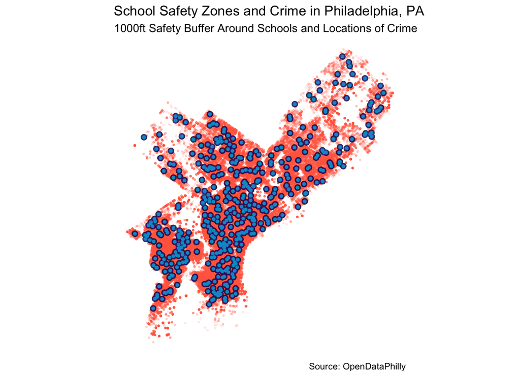

```r
# Map
ggplot() +
  geom_sf(data = crime,
          color = "tomato",
          size = .5,
          alpha = .1) +
   geom_sf(data = school_buffer,
          fill = "navyblue",
          alpha = .8) +
  geom_sf(data = schools,
          color = "deepskyblue3",
          size = 1) +
  labs(
    title = "School Safety Zones and Crime in Philadelphia, PA",
    subtitle = "1000ft Safety Buffer Around Schools and Locations of Crime",
    caption = "Source: OpenDataPhilly") +
  theme_void()
```

**Analysis requirements:** - Clear code comments explaining each step - Appropriate CRS transformations - Summary statistics or counts - At least one map showing your findings - Brief interpretation of results (3-5 sentences)

**Your interpretation:**

Total Crimes: 151,197 Crimes Within 1000ft of schools: 74,198 Percent of Crimes Within 1000ft of Schools: 49.07%

## Finally - A few comments about your incorporation of feedback!

Take a few moments to clean up your markdown document and then write a line or two or three about how you may have incorporated feedback that you recieved after your first assignment.

Hopefully I hid my API key this time! I’ve run into a few issues with that… from GitHub emailing me about it being available for anyone to access to Zhanchao alerting me on my last assignment. Also, I tried to format my data better and add comments throughout.

## Submission Requirements

**What to submit:**

1. **Rendered HTML document posted to your course portfolio** with all code, outputs, maps, and text
   - Use `embed-resources: true` in YAML so it’s a single file
   - All code should run without errors
   - All maps and charts should display correctly

**File naming:** `LastName_FirstName_Assignment2.html` and `LastName_FirstName_Assignment2.qmd`